## **Input SNP Information**

Completed on Thu Apr 06 21:29:49 2023 (Asia/Shanghai), with the runtime of 51 seconds.

> **An interactive table** for user-input SNPs (n=216, being processed). The table includes three columns: 1st column `SNPs` for input dbSNP rsIDs, 2nd column `P-values` for the significance info, and 3rd column `Locus` for genomic locations (the genome build `hg19`). Each SNP listed in the column `SNPs` is hyperlinked to its corresponding `dbSNP` page.

| SNPs | Pvalue | Locus |
| --- | --- | --- |
| &nbsp;rs80174646 | 1e-143 | chr1:67708155-67708155 |
| &nbsp;rs7517847 | 1e-98 | chr1:67681669-67681669 |
| &nbsp;rs2066845 | 6e-94 | chr16:50756540-50756540 |
| &nbsp;rs1992661 | 1e-74 | chr5:40414989-40414989 |
| &nbsp;rs6426833 | 7e-62 | chr1:20171860-20171860 |
| &nbsp;rs17622378 | 2e-55 | chr5:131778452-131778452 |
| &nbsp;rs3197999 | 7e-55 | chr3:49721532-49721532 |
| &nbsp;rs9977672 | 5e-54 | chr21:40463283-40463283 |
| &nbsp;rs469758 | 6e-54 | chr5:96121715-96121715 |
| &nbsp;rs4672505 | 2e-52 | chr2:62560332-62560332 |

[output cut: 206 more lines]

## **Output: Linked Genes**

> **Linked Gene table** contains information on genes (n=407, linked from input SNPs), including the column `GScores` (ranged from 1 to 10) that quantifies the degree to which genes are responsible for genetic associations. `Linked genes` are sorted by their linked gene scores and are hyperlinked to [GeneCards](https://www.genecards.org) for further information. Please refer to **`Evidence table`** for details on the linking evidence.

| Linked genes | GScores | Description |
| --- | --- | --- |
| IL23R | 10 | interleukin 23 receptor |
| RNU6-586P | 9.163 | RNA, U6 small nuclear 586, pseudogene |
| CYLD | 8.733 | CYLD lysine 63 deubiquitinase |
| NOD2 | 8.733 | nucleotide binding oligomerization domain containing 2 |
| IRF1 | 5.265 | interferon regulatory factor 1 |
| IRF1-AS1 | 5.265 | IRF1 antisense RNA 1 |
| APEH | 5.217 | acylaminoacyl-peptide hydrolase |
| BSN | 5.217 | bassoon presynaptic cytomatrix protein |
| MST1 | 5.217 | macrophage stimulating 1 |
| RNF123 | 5.217 | ring finger protein 123 |

[output cut: 397 more lines]

> **Evidence table** displays information on which SNPs (see the column `SNPs`) are used to define linked genes (the column `Linked genes`) based on which evidence (see the column `Evidence`). The column `SNP type` indicates whether the SNP is an input SNP (`Input`) or an additional SNP in linkage disequilibrium (`LD`). The column `Evidence` contains information on the datasets used, such as `Proximity` (indicative of SNPs in proximity), the prefix `PCHiC_` (promoter capture Hi-C datasets), and the prefix `eQTL_` or `pQTL_` (e/pQTL datasets).

| SNPs | SNP type | Linked genes | Evidence |
| --- | --- | --- | --- |
| rs1004820 | LD | IL23R | Proximity_20000bp |
| rs10789230 | LD | IL23R | Proximity_20000bp |
| rs10889673 | LD | IL23R | Proximity_20000bp |
| rs10889677 | LD | IL23R | Proximity_20000bp |
| rs111379368 | LD | IL23R | Proximity_20000bp |
| rs11209026 | LD | IL23R | Proximity_20000bp |
| rs112106127 | LD | IL23R | Proximity_20000bp |
| rs113120270 | LD | IL23R | Proximity_20000bp |
| rs113155999 | LD | IL23R | Proximity_20000bp |
| rs113935720 | LD | IL23R | Proximity_20000bp |

[output cut: 5964 more lines]

## **Output: Enriched Terms**

> **An interactive table** that displays enriched ontology terms based on 407 linked genes. Each enriched term (the columns `Ontology`, `Term ID` and `Term Name`) has the enrichment z-score (`Z-score`), the enrichment significance level (`FDR`), odds ratio (`Odds ratio`) and 95% confidence intervals (`95% CI`), the number (`Num`) and list (`Members`) of member genes that overlap with linked genes. The table is sorted by FDR ascendingly.

| Ontology | Term ID | Term Name | Z-score | FDR | Odds ratio | 95% CI | Num | Members |
| --- | --- | --- | --- | --- | --- | --- | --- | --- |
| EnvironmentalOrganismal | path:hsa04060 | Cytokine-cytokine receptor interaction | 9.78 | 2.1e-12 | 6.05 | [3.91, 9.21] | 36 | CCL11, CCL19, CCL2, CCL20, CCL21, CCL7, CCR5, CD40, CNTF, CTF1, CXCR1, CXCR2, FAS, IFNGR2, IFNLR1, IL10, IL12B, IL18R1, IL19, IL1R1, IL1R2, IL1RL1, IL2, IL23R, IL27, IL2RA, IL6R, LTBR, OSMR, TNFRSF14,… |
| EnvironmentalOrganismal | path:hsa04061 | Viral protein interaction with cytokine and cytokine receptor | 9.04 | 1.2e-08 | 8.31 | [4.53, 14.6] | 18 | CCL11, CCL19, CCL2, CCL20, CCL21, CCL7, CCR5, CXCR1, CXCR2, IL10, IL18R1, IL19, IL2, IL2RA, IL6R, LTBR, TNFRSF14, TNFRSF1A |
| EnvironmentalOrganismal | ImmuneSystem | Immune system | 6.16 | 1.5e-07 | 2.93 | [2.02, 4.26] | 63 | ADCY3, ANTXR2, ASAP2, CARD9, CCL11, CCL19, CCL2, CCL20, CCL21, CCL7, CCR5, CD244, CD28, CD40, CFL1, CXCR1, CXCR2, CYLD, FAS, FCGR2A, FOS, FOSL1, HCK, HDAC7, HSPA6, ICAM1, ICOSLG, IFIH1, IFNGR2, IL10, … |
| EnvironmentalOrganismal | path:hsa04659 | Th17 cell differentiation | 6.84 | 7.6e-06 | 5.93 | [3.09, 10.7] | 15 | FOS, IFNGR2, IL1R1, IL2, IL23R, IL27, IL2RA, IL6R, JAK2, NFKB1, PRKCQ, RORC, SMAD3, STAT3, TYK2 |
| EnvironmentalOrganismal | path:hsa04630 | JAK-STAT signaling pathway | 6.29 | 1.2e-05 | 4.66 | [2.59, 7.99] | 18 | CNTF, CTF1, IFNGR2, IFNLR1, IL10, IL12B, IL19, IL2, IL23R, IL2RA, IL6R, JAK2, OSMR, PDGFB, PTPN2, SOCS1, STAT3, TYK2 |
| EnvironmentalOrganismal | path:hsa04064 | NF-kappa B signaling pathway | 6.49 | 1.7e-05 | 5.73 | [2.92, 10.5] | 14 | CCL19, CCL21, CD40, CYLD, ICAM1, IL1R1, LTBR, NFKB1, PLAU, PRKCB, PRKCQ, TLR4, TNFAIP3, TNFRSF1A |
| EnvironmentalOrganismal | SignalingMoleculesAndInteraction | Signaling molecules and interaction | 4.99 | 3.1e-05 | 2.48 | [1.68, 3.63] | 48 | CCL11, CCL19, CCL2, CCL20, CCL21, CCL7, CCR5, CD226, CD28, CD40, CD6, CNTF, CTF1, CXCR1, CXCR2, DAG1, FAS, GCG, GPR35, ICAM1, ICAM3, ICOSLG, IFNGR2, IFNLR1, IL10, IL12B, IL18R1, IL19, IL1R1, IL1R2, IL… |
| EnvironmentalOrganismal | SignalTransduction | Signal transduction | 4.27 | 0.00016 | 2.18 | [1.49, 3.21] | 77 | ACTA2, ADCY3, BRAP, CACNA1S, CCL19, CCL2, CCL20, CCL21, CD40, CDC37, CNTF, CTF1, CUL2, CXCR1, CXCR2, CYLD, DGKE, EFNA1, ETS1, FAS, FOS, FOSL1, GCG, GNA12, HES5, HNF4A, HSPA6, ICAM1, IFNGR2, IFNLR1, IL… |
| EnvironmentalOrganismal | path:hsa04668 | TNF signaling pathway | 5.51 | 0.00016 | 4.73 | [2.36, 8.8] | 13 | CCL2, CCL20, FAS, FOS, ICAM1, IL18R1, IRF1, MAP3K8, NFKB1, NOD2, RPS6KA4, TNFAIP3, TNFRSF1A |
| EnvironmentalOrganismal | path:hsa04658 | Th1 and Th2 cell differentiation | 5.19 | 0.0005 | 4.83 | [2.26, 9.43] | 11 | FOS, IFNGR2, IL12B, IL2, IL2RA, JAK2, NFKB1, NOTCH1, PRKCQ, RUNX3, TYK2 |

[output cut: 66 more lines]

## **Output: Dotplot**

> **A dotplot** of enriched ontology terms identified using Fisher’s exact test. An editable pdf file is also available for download.

DOWNLOAD .pdf

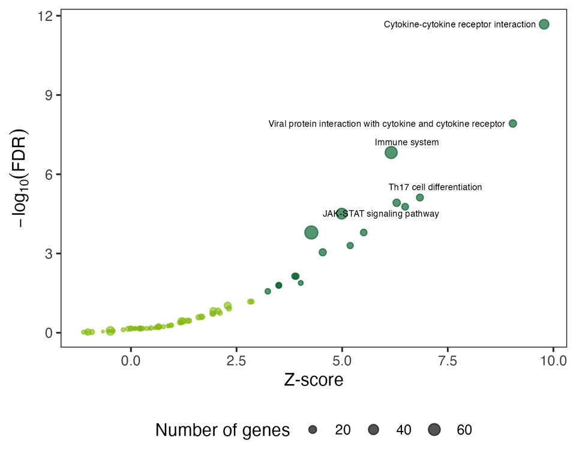

Figure 1: A dotplot of enriched ontology terms. The dots colored in dark green represent the terms with FDR < 0.05, indicating statistical significance. The top 5 significant terms (ordered by FDR ascendingly) are labelled for easier interpretation.

## **Output: Forest Plot**

> **A forest plot** of enriched ontology terms identified using Fisher’s exact test. An editable pdf file is also available for download.

DOWNLOAD .pdf

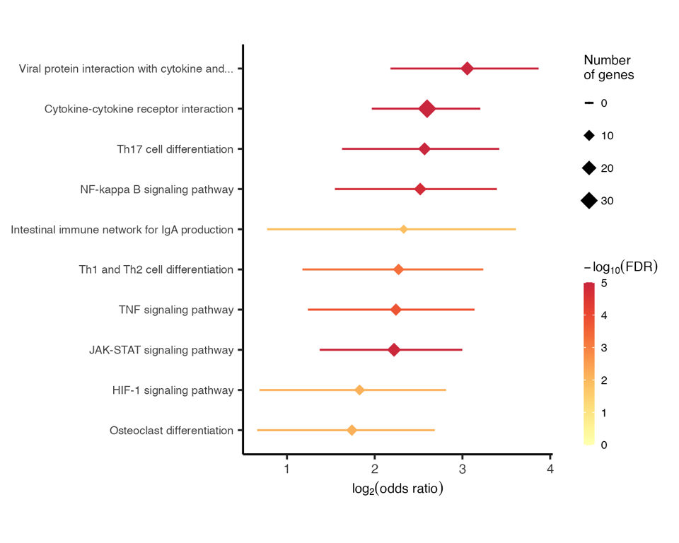

Figure 2: Forest plot for enriched ontology terms (ordered by odds ratio descendingly).